# filters VCF for ploidy = 1

#!/usr/bin/env Rscript

#==========================================================#

##### Filters VCF files

###### Authors : Stefano Mona / Romuald Laso-Jadart / Elise Gay

###### nov 2023

#==========================================================#

##### Load Libraries

```r
library(ggplot2)
library(reshape2)
library(gridExtra)
library(stringr)
```

#### Load functions to apply filters on genotype and depth

```r
# for filters on sequencing depth
source("R_functions_ploidy1/fonction_filtre_cover.R")
# for filters on genotypes (heterozygous rate ; homozygous ; missing data)
# Each function can be used to filters individuals or positions based on genotype rates
source("R_functions_ploidy1/Filter_Het.R")
```

[output not shown]

```r
source("R_functions_ploidy1/Filter_Hom_ref.R")
source("R_functions_ploidy1/Filter_Na.R")
```

#### get/set dir

```r
getwd()
```

```
## [1] "C:/Users/elise/OneDrive - MNHN/museum/Shared_tools/WGS Variant Calling on Y chromosome"
```

#### Input VCF Files + Description

#### Example :

’’’

#———————————————————————————————–#

# VCF on Y chromosome. Variant calling called with ploidy = 1

# VCF already filtered for lowqual, indel and repeat. Made from GATK filters on cluster account

# 25 male rats samples (data from Romuald Laso-Jadart dataset)

#———————————————————————————————–#

’’’

```r
knitr::opts_chunk$set(warning = FALSE, message = FALSE)

VCF=read.vcfR("data/PPC_M_NC_051357.1_DP100_MQ40_GATK_TAG_Flowqual_Noindels_Norepeat_SNP.vcf.gz")
```

[output not shown]

#### Read metadata

```r
knitr::opts_chunk$set(warning = FALSE, message = FALSE)

metadata=read.table("metadata/metadata.txt", header=TRUE)
metadata
```

```
##             samples_site
## ALK20             Alaska
## ANR0085_S11        Paris
## ANR0086_S14        Paris
## CAL79         California
## CN001              china
## CN002              china
## CN009              china
## CN010              china
## KHM07           Cambodia
## NLD21        Netherlands
## PAR005_S10         Paris
## PAR009_S22         Paris
## PAR057_S2          Paris
## PAR083_S23         Paris
## PAR090_S20         Paris
## PAR1920_S13        Paris
## PAR1934_S8         Paris
## PAR320_S1          Paris
## PAR341_S6          Paris
## PAR379_S16         Paris
## PAR412_S7          Paris
## PAR993_S19         Paris
## PHL09           philipin
## PZP033_S12         Paris
## SWE35             sweden
```

#### 1) Sequencing depth rate visualization

###### Get and format DP table for all position and all individuals

###### get the position sequencing depth

```r
knitr::opts_chunk$set(warning = FALSE, message = FALSE)

DP<- extract.gt(VCF, element='DP', as.numeric = TRUE)
head(DP)
```

```
##                   ALK20 ANR0085_S11 ANR0086_S14 CAL79 CN001 CN002 CN009 CN010
## NC_051357.1_13169    21          12          13    18     8     3     4     8
## NC_051357.1_16096     7          25          17    14    13     6    14     8
## NC_051357.1_17705    23          14          12    25     8    10    12     8
## NC_051357.1_17810    14          20          15    21     7    10    13    10
## NC_051357.1_17869    10          18          11    20     9     9    12    11
## NC_051357.1_18030    14          17          17    14    14    10    14    12
##                   KHM07 NLD21 PAR005_S10 PAR009_S22 PAR057_S2 PAR083_S23
## NC_051357.1_13169    11    10         22         31        16         13
## NC_051357.1_16096    21    15         21         22        17         17
## NC_051357.1_17705    10    11         21         24        17         21
## NC_051357.1_17810     8    15         26         26        25         25
## NC_051357.1_17869    11    14         19         23        22         24
## NC_051357.1_18030    10    10         33         29        16         34
##                   PAR090_S20 PAR1920_S13 PAR1934_S8 PAR320_S1 PAR341_S6
## NC_051357.1_13169         27          26         12        22        22
## NC_051357.1_16096         19          29         12        20        21
## NC_051357.1_17705         29          24         13        16        13
## NC_051357.1_17810         28          20         16        16        18
## NC_051357.1_17869         27          20         14        13        16
## NC_051357.1_18030         30          22         25        21        12
##                   PAR379_S16 PAR412_S7 PAR993_S19 PHL09 PZP033_S12 SWE35
## NC_051357.1_13169          9        18         14    14         20    19
## NC_051357.1_16096         13        14         18    14         21    10
## NC_051357.1_17705         17        18         26    13         20    20
## NC_051357.1_17810         26        17         23    13         26    14
## NC_051357.1_17869         24        15         20    11         21    14
## NC_051357.1_18030         10        18          7    14         34    14
```

```r
summary(DP)
```

```
##      ALK20         ANR0085_S11    ANR0086_S14          CAL79
##  Min.   :   0.0   Min.   :   0   Min.   :   0.00   Min.   :   0.00
##  1st Qu.:  23.0   1st Qu.:  27   1st Qu.:  22.00   1st Qu.:  21.00
##  Median :  43.0   Median :  51   Median :  41.00   Median :  37.00
##  Mean   : 121.8   Mean   : 128   Mean   :  99.38   Mean   :  85.48
##  3rd Qu.: 128.0   3rd Qu.: 131   3rd Qu.: 100.00   3rd Qu.:  77.00
##  Max.   :2501.0   Max.   :3043   Max.   :2645.00   Max.   :3115.00
##
##      CN001             CN002           CN009             CN010
##  Min.   :   0.00   Min.   :  0.0   Min.   :   0.00   Min.   :   0.00
##  1st Qu.:  11.00   1st Qu.: 11.0   1st Qu.:  15.00   1st Qu.:  15.00
##  Median :  20.00   Median : 19.0   Median :  27.00   Median :  27.00
##  Mean   :  47.29   Mean   : 44.3   Mean   :  65.11   Mean   :  62.25
##  3rd Qu.:  44.00   3rd Qu.: 43.0   3rd Qu.:  61.00   3rd Qu.:  58.00
##  Max.   :1536.00   Max.   :901.0   Max.   :2063.00   Max.   :2017.00
##                    NA's   :1
##      KHM07             NLD21           PAR005_S10       PAR009_S22
##  Min.   :   0.00   Min.   :   0.00   Min.   :   0.0   Min.   :   0.0
##  1st Qu.:  17.00   1st Qu.:  17.00   1st Qu.:  35.0   1st Qu.:  37.0
##  Median :  32.00   Median :  29.00   Median :  64.0   Median :  66.0
##  Mean   :  68.84   Mean   :  58.84   Mean   : 157.9   Mean   : 184.1
##  3rd Qu.:  72.75   3rd Qu.:  60.00   3rd Qu.: 157.0   3rd Qu.: 189.8
##  Max.   :1356.00   Max.   :1174.00   Max.   :3420.0   Max.   :4245.0
##
##    PAR057_S2        PAR083_S23       PAR090_S20      PAR1920_S13
##  Min.   :   0.0   Min.   :   0.0   Min.   :   0.0   Min.   :   0.0
##  1st Qu.:  25.0   1st Qu.:  31.0   1st Qu.:  40.0   1st Qu.:  40.0
##  Median :  46.0   Median :  58.0   Median :  74.0   Median :  70.0
##  Mean   : 115.1   Mean   : 144.3   Mean   : 202.3   Mean   : 175.2
##  3rd Qu.: 116.0   3rd Qu.: 147.0   3rd Qu.: 198.0   3rd Qu.: 184.0
##  Max.   :3047.0   Max.   :3492.0   Max.   :4171.0   Max.   :4312.0
##
##    PAR1934_S8       PAR320_S1        PAR341_S6        PAR379_S16
##  Min.   :   0.0   Min.   :   0.0   Min.   :   0.0   Min.   :   0.0
##  1st Qu.:  26.0   1st Qu.:  28.0   1st Qu.:  24.0   1st Qu.:  19.0
##  Median :  47.0   Median :  51.0   Median :  43.0   Median :  36.0
##  Mean   : 122.6   Mean   : 132.1   Mean   : 101.9   Mean   : 103.9
##  3rd Qu.: 128.0   3rd Qu.: 132.0   3rd Qu.: 104.0   3rd Qu.:  99.0
##  Max.   :3565.0   Max.   :3241.0   Max.   :3390.0   Max.   :3573.0
##                                                     NA's   :1
##    PAR412_S7        PAR993_S19         PHL09           PZP033_S12
##  Min.   :   0.0   Min.   :   0.0   Min.   :   0.00   Min.   :   0.0
##  1st Qu.:  23.0   1st Qu.:  33.0   1st Qu.:  16.00   1st Qu.:  35.0
##  Median :  43.0   Median :  58.0   Median :  31.00   Median :  65.0
##  Mean   : 119.4   Mean   : 143.8   Mean   :  89.07   Mean   : 173.1
##  3rd Qu.: 123.0   3rd Qu.: 149.0   3rd Qu.:  92.00   3rd Qu.: 178.0
##  Max.   :2216.0   Max.   :3338.0   Max.   :1948.00   Max.   :3541.0
##
##      SWE35
##  Min.   :   0.00
##  1st Qu.:  18.25
##  Median :  34.00
##  Mean   :  82.27
##  3rd Qu.:  84.00
##  Max.   :1957.00
##
```

###### get mean per column (individu)

```r
knitr::opts_chunk$set(warning = FALSE, message = FALSE)

moyenne_cover_par_indiv = apply(DP,2,mean,na.rm=T)
moyenne_cover_par_Ind_table=as.data.frame(moyenne_cover_par_indiv)
```

###### summarise the data per individual

```r
knitr::opts_chunk$set(warning = FALSE, message = FALSE)

head(moyenne_cover_par_Ind_table)
```

```
##             moyenne_cover_par_indiv
## ALK20                     121.82698
## ANR0085_S11               128.00869
## ANR0086_S14                99.37903
## CAL79                      85.47967
## CN001                      47.29273
## CN002                      44.30161
```

```r
summary(moyenne_cover_par_indiv)
```

```
##    Min. 1st Qu.  Median    Mean 3rd Qu.    Max.
##   44.30   82.27  115.10  113.13  143.82  202.27
```

```r
moyenne_cover_par_indiv
```

```
##       ALK20 ANR0085_S11 ANR0086_S14       CAL79       CN001       CN002
##   121.82698   128.00869    99.37903    85.47967    47.29273    44.30161
##       CN009       CN010       KHM07       NLD21  PAR005_S10  PAR009_S22
##    65.10992    62.25443    68.83769    58.83533   157.91952   184.06867
##   PAR057_S2  PAR083_S23  PAR090_S20 PAR1920_S13  PAR1934_S8   PAR320_S1
##   115.10081   144.33761   202.26784   175.22187   122.55736   132.05087
##   PAR341_S6  PAR379_S16   PAR412_S7  PAR993_S19       PHL09  PZP033_S12
##   101.94702   103.88830   119.35650   143.82419    89.06605   173.12021
##       SWE35
##    82.27375
```

###### get mean per line (position)

```r
knitr::opts_chunk$set(warning = FALSE, message = FALSE)

moyenne_cover_par_pos= apply(DP,1,mean,na.rm=T)
moyenne_cover_par_pos_table=as.data.frame(moyenne_cover_par_pos)
```

###### summarise the data per position

```r
knitr::opts_chunk$set(warning = FALSE, message = FALSE)

head(moyenne_cover_par_pos)
```

```
## NC_051357.1_13169 NC_051357.1_16096 NC_051357.1_17705 NC_051357.1_17810
##             15.72             16.32             17.00             18.08
## NC_051357.1_17869 NC_051357.1_18030
##             16.32             18.04
```

```r
summary(moyenne_cover_par_pos)
```

```
##    Min. 1st Qu.  Median    Mean 3rd Qu.    Max.
##    0.36   27.20   47.04  113.13  118.79 2127.80
```

###### Get the position vector in numeric

```r
knitr::opts_chunk$set(warning = FALSE, message = FALSE)

head(rownames(DP))
```

```
## [1] "NC_051357.1_13169" "NC_051357.1_16096" "NC_051357.1_17705"
## [4] "NC_051357.1_17810" "NC_051357.1_17869" "NC_051357.1_18030"
```

```r
knitr::opts_chunk$set(warning = FALSE, message = FALSE)

position_vector=as.numeric(str_remove(rownames(DP), "NC_051357.1_"))
head(position_vector)
```

```
## [1] 13169 16096 17705 17810 17869 18030
```

###### Add vector of position in the sequencing depth table

```r
knitr::opts_chunk$set(warning = FALSE, message = FALSE)

moyenne_cover_par_pos_table_pos=cbind(moyenne_cover_par_pos_table, position_vector)
head(moyenne_cover_par_pos_table_pos)
```

```
##                   moyenne_cover_par_pos position_vector
## NC_051357.1_13169                 15.72           13169
## NC_051357.1_16096                 16.32           16096
## NC_051357.1_17705                 17.00           17705
## NC_051357.1_17810                 18.08           17810
## NC_051357.1_17869                 16.32           17869
## NC_051357.1_18030                 18.04           18030
```

```r
dim(moyenne_cover_par_pos_table_pos)
```

```
## [1] 11854     2
```

#### PLOT detailed DP for each ind or position

##### plot DP by positions

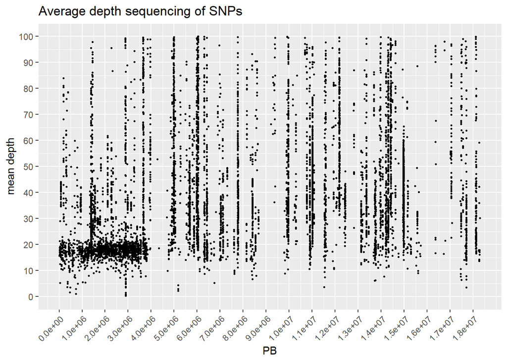

```r
knitr::opts_chunk$set(warning = FALSE, message = FALSE)

ggplot()+
  geom_point(data=moyenne_cover_par_pos_table_pos,
             aes(y=moyenne_cover_par_pos_table_pos$moyenne_cover_par_pos,
                 x=moyenne_cover_par_pos_table_pos$position_vector),
             color="black", pch=20, size=1) +

  theme(axis.text.x = element_text(angle = 45, vjust = 1, hjust=1)) +
  labs(y="mean depth", x = "PB")+
  ggtitle("Average depth sequencing of SNPs")+
  scale_x_continuous(breaks = seq(0, 18e+06, by = 1000000)) +
  # vizualise only range of sequencing depth detph
  scale_y_continuous(breaks = seq(0, 100, by = 10), limits = c(0,100))
```

##### boxplot DP by individuals

- format table

[figure not shown]

```r
knitr::opts_chunk$set(warning = FALSE, message = FALSE)

DP_melt=melt(DP)

ggplot()+
  geom_boxplot(data=DP_melt, aes(x=DP_melt$Var2,
                                 y=DP_melt$value,
                                 colour="purple"),
               color="black") +
  theme(axis.title.x=element_blank())+
  labs(y="SNP sequencing depth", x = "samples")+
  ggtitle("depth sequencing distribution of SNP filtered on 13 males on the R2 region in the Y chromosome") +
  theme(axis.text.x = element_text(angle = 45, vjust = 1, hjust=1)) +
  # vizualise only range of sequencing depth detph
  scale_y_continuous(breaks = seq(0, 260, by = 20), limits = c(0, 260))
```

#### 2) Vizualisation of chosen genotype frequency

##### Plot count and proportion

- Extract genotype

```r
geno<-extract.gt(VCF,element="GT",mask=F,as.numeric=F,return.alleles = F,
                   convertNA = F,extract = T)
geno_table=as.data.frame(geno)
head(geno_table)
```

```
##                   ALK20 ANR0085_S11 ANR0086_S14 CAL79 CN001 CN002 CN009 CN010
## NC_051357.1_13169     0           0           0     1     1     .     .     0
## NC_051357.1_16096     0           0           0     0     0     0     0     0
## NC_051357.1_17705     0           0           0     0     0     0     0     0
## NC_051357.1_17810     0           0           0     0     1     0     1     0
## NC_051357.1_17869     0           0           0     0     0     0     0     0
## NC_051357.1_18030     0           0           0     1     1     1     1     0
##                   KHM07 NLD21 PAR005_S10 PAR009_S22 PAR057_S2 PAR083_S23
## NC_051357.1_13169     1     0          0          0         0          0
## NC_051357.1_16096     1     0          0          0         0          0
## NC_051357.1_17705     1     0          0          0         0          0
## NC_051357.1_17810     0     0          0          0         0          0
## NC_051357.1_17869     1     0          0          0         0          0
## NC_051357.1_18030     1     0          0          0         0          0
##                   PAR090_S20 PAR1920_S13 PAR1934_S8 PAR320_S1 PAR341_S6
## NC_051357.1_13169          0           0          0         0         0
## NC_051357.1_16096          0           0          0         0         0
## NC_051357.1_17705          0           0          0         0         0
## NC_051357.1_17810          0           0          0         0         0
## NC_051357.1_17869          0           0          0         0         0
## NC_051357.1_18030          0           0          0         0         0
##                   PAR379_S16 PAR412_S7 PAR993_S19 PHL09 PZP033_S12 SWE35
## NC_051357.1_13169          0         0          0     0          0     0
## NC_051357.1_16096          0         0          0     0          0     0
## NC_051357.1_17705          0         0          0     0          0     0
## NC_051357.1_17810          0         0          0     0          0     0
## NC_051357.1_17869          0         0          0     0          0     0
## NC_051357.1_18030          0         0          0     0          0     0
```

- Raw Count of genotype

```r
# In rowsum and colsum the number of '.' '1' and '0'and compute genotype count

# By position
sum_pos_geno_table = as.data.frame(rowSums(geno==".")) # put ".", "0" or "1" depending on the genotype you want to count
head(sum_pos_geno_table)
```

```
##                   rowSums(geno == ".")
## NC_051357.1_13169                    2
## NC_051357.1_16096                    0
## NC_051357.1_17705                    0
## NC_051357.1_17810                    0
## NC_051357.1_17869                    0
## NC_051357.1_18030                    0
```

```r
dim(sum_pos_geno_table)
```

```
## [1] 11854     1
```

```r
# By individuals
sum_ind_geno_table = as.data.frame(colSums(geno=="."))
dim(sum_ind_geno_table)
```

```
## [1] 25  1
```

```r
summary(sum_ind_geno_table)
```

```
##  colSums(geno == ".")
##  Min.   :2815
##  1st Qu.:3201
##  Median :4032
##  Mean   :3961
##  3rd Qu.:4421
##  Max.   :5174
```

- Genotype frequency

```r
# By position
Prop_Pos_geno=((sum_pos_geno_table/dim(geno_table)[2])*100)
head(Prop_Pos_geno)
```

```
##                   rowSums(geno == ".")
## NC_051357.1_13169                    8
## NC_051357.1_16096                    0
## NC_051357.1_17705                    0
## NC_051357.1_17810                    0
## NC_051357.1_17869                    0
## NC_051357.1_18030                    0
```

```r
summary(Prop_Pos_geno)
```

```
##  rowSums(geno == ".")
##  Min.   :  0.00
##  1st Qu.:  0.00
##  Median : 16.00
##  Mean   : 33.41
##  3rd Qu.: 68.00
##  Max.   :100.00
```

```r
Prop_Pos_geno_table=as.data.frame(Prop_Pos_geno)
```

```r
# Get the position vector in numeric
head(rownames(Prop_Pos_geno_table))
```

```
## [1] "NC_051357.1_13169" "NC_051357.1_16096" "NC_051357.1_17705"
## [4] "NC_051357.1_17810" "NC_051357.1_17869" "NC_051357.1_18030"
```

```r
position_vector=as.numeric(str_remove(rownames(Prop_Pos_geno_table), "NC_051357.1_"))
```

```r
# Add vector of position in the sequencing depth table
Prop_Pos_geno_table_pos=cbind(Prop_Pos_geno_table, position_vector)
head(Prop_Pos_geno_table_pos)
```

```
##                   rowSums(geno == ".") position_vector
## NC_051357.1_13169                    8           13169
## NC_051357.1_16096                    0           16096
## NC_051357.1_17705                    0           17705
## NC_051357.1_17810                    0           17810
## NC_051357.1_17869                    0           17869
## NC_051357.1_18030                    0           18030
```

```r
dim(Prop_Pos_geno_table_pos)
```

```
## [1] 11854     2
```

```r
# By individuals
Prop_Ind_geno=((sum_ind_geno_table/dim(geno_table)[1])*100)
head(Prop_Ind_geno)
```

```
##             colSums(geno == ".")
## ALK20                   37.12671
## ANR0085_S11             37.02548
## ANR0086_S14             31.93859
## CAL79                   27.00354
## CN001                   23.93285
## CN002                   24.56555
```

```r
summary(Prop_Ind_geno)
```

```
##  colSums(geno == ".")
##  Min.   :23.75
##  1st Qu.:27.00
##  Median :34.01
##  Mean   :33.41
##  3rd Qu.:37.30
##  Max.   :43.65
```

```r
Prop_Ind_geno_table=as.data.frame(Prop_Ind_geno)
Prop_Ind_geno_table
```

```
##             colSums(geno == ".")
## ALK20                   37.12671
## ANR0085_S11             37.02548
## ANR0086_S14             31.93859
## CAL79                   27.00354
## CN001                   23.93285
## CN002                   24.56555
## CN009                   26.42990
## CN010                   25.02953
## KHM07                   25.55256
## NLD21                   23.74726
## PAR005_S10              39.58158
## PAR009_S22              41.94365
## PAR057_S2               34.01383
## PAR083_S23              38.63675
## PAR090_S20              43.64771
## PAR1920_S13             42.07862
## PAR1934_S8              35.35515
## PAR320_S1               36.12283
## PAR341_S6               32.14949
## PAR379_S16              33.33896
## PAR412_S7               35.27079
## PAR993_S19              37.29543
## PHL09                   31.87953
## PZP033_S12              41.16754
## SWE35                   30.43698
```

#### PLOT genotype frequencies

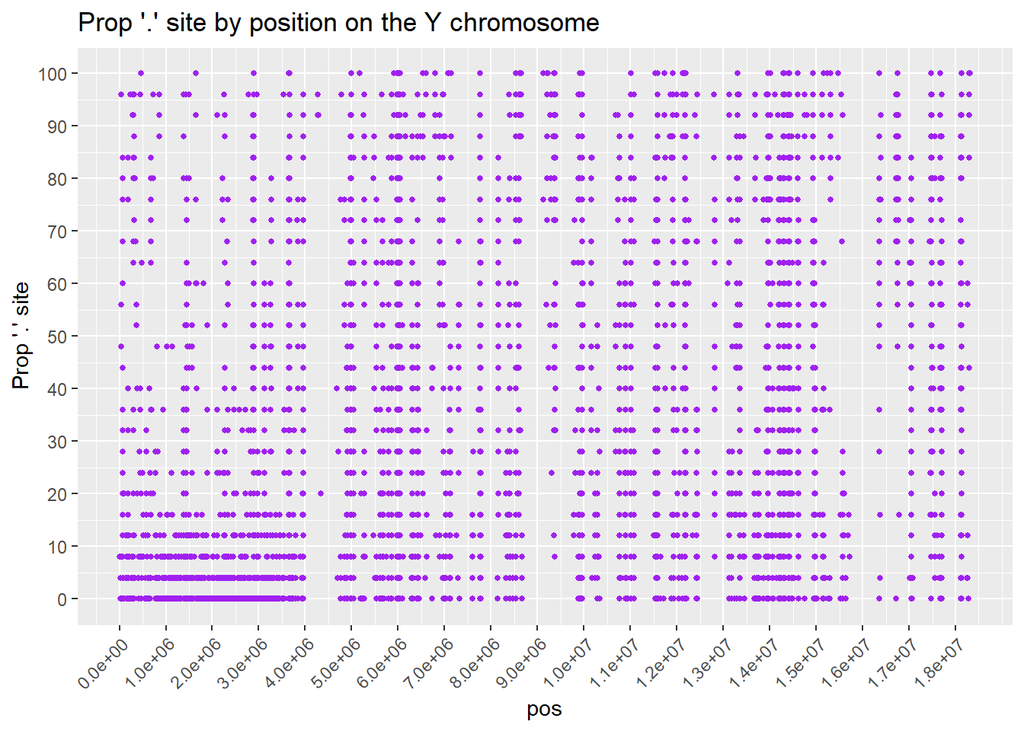

```r
# By position
ggplot()+
  geom_point(data=Prop_Pos_geno_table_pos,
             aes(y=Prop_Pos_geno_table_pos$`rowSums(geno == ".")` ,
                 x=Prop_Pos_geno_table_pos$position_vector),
             color="purple",
             size=1)+
  labs(x="pos", y = "Prop '.' site") +
  ggtitle("Prop '.' site by position on the Y chromosome") +
  scale_x_continuous(breaks = seq(0, position_vector[length(position_vector)],
                                  by = 1000000)) +
  scale_y_continuous(breaks = seq(0, 100, by = 10), limits = c(0,100)) +
  theme(axis.text.x = element_text(angle = 45, vjust = 1, hjust=1))
```

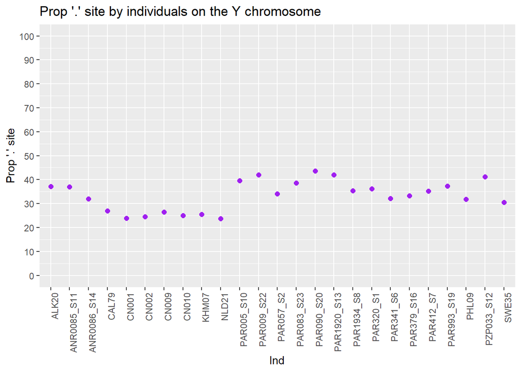

```r
# By indivduals
ggplot()+
  geom_point(data=Prop_Ind_geno_table,
             aes(y=Prop_Ind_geno_table$`colSums(geno == ".")` ,
                 x=row.names(Prop_Ind_geno_table)),
             color="purple",
             size=2) +
  labs(x="Ind", y = "Prop '.' site") +
  ggtitle("Prop '.' site by individuals on the Y chromosome") +
  theme(axis.text.x = element_text(angle = 90, vjust = 1, hjust=1)) +
  scale_y_continuous(breaks = seq(0, 100, by = 10), limits = c(0,100))
```

#### 3) Apply filters

##### Example of filters by individuals

```r
colnames(VCF@gt)
```

```
##  [1] "FORMAT"      "ALK20"       "ANR0085_S11" "ANR0086_S14" "CAL79"
##  [6] "CN001"       "CN002"       "CN009"       "CN010"       "KHM07"
## [11] "NLD21"       "PAR005_S10"  "PAR009_S22"  "PAR057_S2"   "PAR083_S23"
## [16] "PAR090_S20"  "PAR1920_S13" "PAR1934_S8"  "PAR320_S1"   "PAR341_S6"
## [21] "PAR379_S16"  "PAR412_S7"   "PAR993_S19"  "PHL09"       "PZP033_S12"
## [26] "SWE35"
```

```r
VCF_subset = VCF[,c("FORMAT","ALK20","ANR0085_S11","ANR0086_S14","CAL79","CN001","CN002")]
```

##### Functions description

’’’

- For DP filters

  # ARGUMENTS : fun_filtre_cover<-function(vcf,taux_min_cover_pos,taux_max_cover_pos,taux_min_cover_ind,taux_max_cover_ind){

  # taux_min_cover_pos : int, min average DP by positions

  # taux_max_cover_pos : int, max average DP by positions

  # taux_min_cover_ind : int, min average DP by individuals

  # taux_max_cover_ind : int, max average DP by individuals
- For Na filters

  # ARGUMENTS :function(vfc,rate_na_max_POS,rate_na_max_Ind)

  # Method :

  # sum of “genotype” in vcf@gt has to be inferior or equal to the rate chosen in arg (which(rate_na_ind<=rate_na_max_Ind))

  # The filters is first applied on individuals and then on position
- For rate of heterozygous sites filters

  # ARGUMENTS :

  # rate_het_max_POS (double) : Max percent of heterozygous site in one position

  # rate_het_max_Ind (double) : Max percent of heterozygous site in one individus

  # rate_het_min_pos (int) : Min nb of heterozygous site in one position

  # Method :

  # sum of “genotype” in vcf@gt has to be inferior or equal to the rate chosen in arg (which(rate_het_ind<=rate_het_max_Ind))

  # The filters is first applied on individuals and then on position

’’’

#### Run the loop

- examples of filters on raw vcf and vcf subset

```r
dir_data="data/"
VCF_lists=c("VCF", "VCF_subset")
```

- Run filters on the VCF list

```r
for (vcf in VCF_lists){
  name_vcf=get(vcf)
  # filter for DP
  VCF_DP_10_100<-fun_filtre_cover(name_vcf, 10, 100, 10, 200)

  # filter for Na (0% by position)
  VCF_DP_10_100_Na0=Filters_na_Ind_Pos(VCF_DP_10_100,0.0,0.0)

  # other filters with NA < 20% by positions and 30% by individuals
  VCF_DP_10_100_Na20_30=Filters_na_Ind_Pos(VCF_DP_10_100,20.0,30.0)

  # save vcf filtered
  file_name_na=paste(dir_data,"Rats_Y_P1_DP100_Flowqual_Noindels_Norepeat_DP10_100_Na0_", vcf, "_vcf.gz", sep = "")
  write.vcf(VCF_DP_10_100_Na0, paste(dir_data,"Rats_Y_DP10_100_Na0.vcf.gz", sep = ""))
  write.vcf(VCF_DP_10_100_Na20_30, paste(dir_data,"Rats_Y_DP10_100_Na20_30.vcf.gz", sep = ""))
}
```

- Check for data

```r
dir(dir_data)
```

```
## [1] "PPC_M_NC_051357.1_DP100_MQ40_GATK_TAG_Flowqual_Noindels_Norepeat_SNP.vcf.gz"
## [2] "PPC_M_NC_051357.1_DP100_MQ40_GATK_TAG_Flowqual_Noindels_Norepeat_SNP.vcf.gz.csi"
## [3] "Rats_Y_DP10_100_Na0.vcf.gz"
## [4] "Rats_Y_DP10_100_Na20_30.vcf.gz"
```

#### To check your filters, re-run the script on the filtered vcfs